# Optimal giving up new plots

Now that we have dropped our arbitrary strength measure, there is the question of how to compare model prediction to behavior. Here are plots in which we do our best to simulate the full task and behavioral predictors (judgements and pre-test accuracy).

This is a new version of the model using Gaussian samplse rather than Binomial. Having separate control over the mean and variance allowed me to get a much tighter fit than with the Binomial, where mean and variance are tied.

```r
plot_both = function(x, y) {
    df %>%
        ggplot(aes({{x}}, {{y}}, color=name, linetype=name)) +
        stat_summary(fun.data=mean_cl_boot, size=.5) +
        stat_summary(fun=mean, geom="line") +
        facet_wrap(~response_type) +
        theme(legend.position="none") +
        scale_colour_manual(values=c(
            'Human'='gray10',
            'Model'='#9D6BE0'
        ), aesthetics=c("fill", "colour"), name="")
}
```

## Memamemory judgements

The model judgement is comptued based on the estimated memory strength (drift rate) when the trial terminates. Then we bin by quintile (across both skip and correct) to get an ordinal judgement.

Model prediction is the dashed purple line.

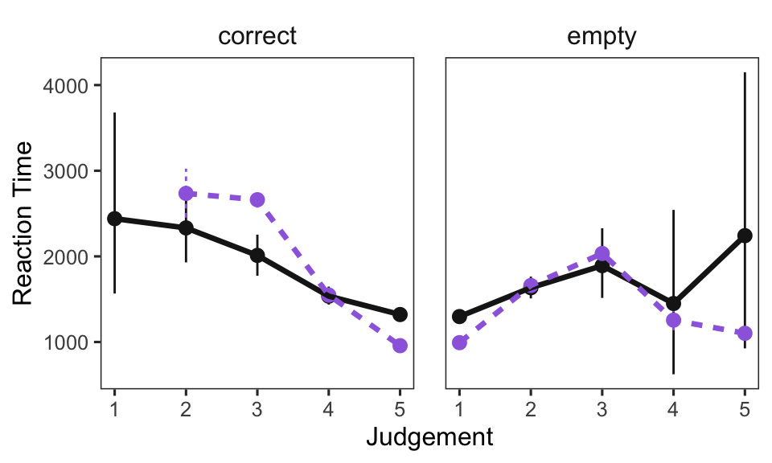

```r
plot_both(judgement_alt, rt) +
    facet_wrap(~response_type) +
    labs(x="Judgement", y='Reaction Time') +
    scale_x_continuous(n.breaks=5)
```

Two notes. First, the non-monotonic prediction for skip trials is very odd and I need to look into this further.

Second, quintiles is not necessarily the best approach. The plot below shows the distribution of judgements. In the human data, the extremes are over-represented, which I think is typical of Likert responses. Ordinal regression models account for this by assuming an underlying continuous variable that is mapped onto the discrete variable with arbitrary cutoff points. We could do something like this to better match the judgement distribution.

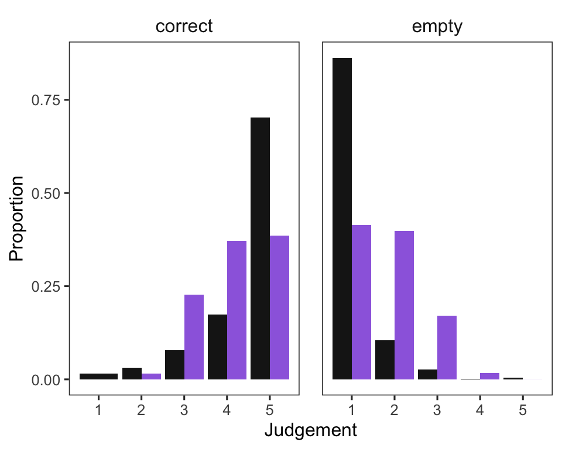

```r
df %>% ggplot(aes(judgement_alt, ..prop.., fill=name)) +
    geom_bar(position="dodge") +
    facet_wrap(~response_type) +
    theme(legend.position="none") +
    scale_colour_manual(values=c(
        'Human'='gray10',
        'Model'='#9D6BE0'
    ), aesthetics=c("fill", "colour"), name="") +
    labs(x="Judgement", y='Proportion')
```

Here is an alternative version where we use quintiles within response type.

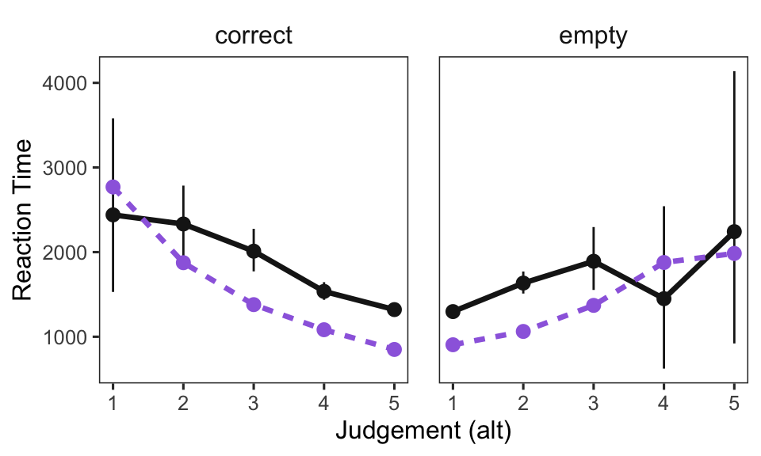

```r
plot_both(judgement, rt) +
    facet_wrap(~response_type) +
    labs(x="Judgement (alt)", y='Reaction Time') +
    scale_x_continuous(n.breaks=5)
```

## Pretest-accuracy

To simulate the pre-test accuracy plot, we start with 10,000 simulated pairs (each defined by a true memory strength). We simulate recalling each one twice, giving us our pre-test accuracy measure. Then we add Guassian noise to each strength to capture drifting memory strength, similar to [Sikstrom and Jonsson (2005)](https://pubmed.ncbi.nlm.nih.gov/16262474/). Finally, we simulate each “pair” one more time for the criticial trial.

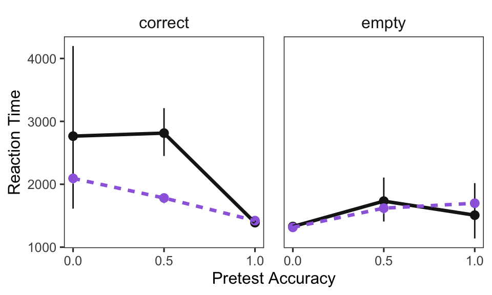

```r
plot_both(pre_correct, rt) +
    facet_wrap(~response_type) +
    labs(x="Pretest Accuracy", y='Reaction Time') +
    scale_x_continuous(n.breaks=3)
```

Not the tightest fit here, but I chose the parameters to look good on the pilot data, so we might be able to get a better fit. (Note: we might actually be able to do likelihood-based fitting with this model).

A nuaance: Currently, I’m assuming the same parameters as in the critical trials, which doesn’t really make sense because the incentives are different. I don’t love the idea of having separate parameters though. One thing we could try is to ditch the pretest/posttest design and use the same incentives throughout (with skipping and high time penalties). We would use performance on the first two trials to predict performance on the third. This would definitely be the cleanest design. But it might reduce our sensitivity too much, as people will skip on trials they might have answered correctly. They could also remember having skipped it before and just immediately skip it. This might be helped by putting the distractor in between the second and third (critical) round of test trials.

## Early skipping probability

Finally, a totally new plot! The idea here is to more clearly illustrate the *utility* of metamemory. The results on skip trials don’t realy do this because ultimately the target was not recalled, so spending more time didn’t actually help.

Take all the trials in which the target wasn’t recalled in the first second (roughly median RT). These trials can be of two type: either the person skipped in the first second, or they stuck with it (perhaps correctly recalling it after one second, perhaps not). Call the first type a “fast skip”. Clearly, it is best to fast skip on trials where you are unlikely to recall, and you should definitely not fast skip on trials where you are likely to recall. This is exactly what we see.

Note that this analysis has way more power than the RT-on-skips analysis because it doesn’t depend on the rare cases where people skip a target they have a strong memory of.

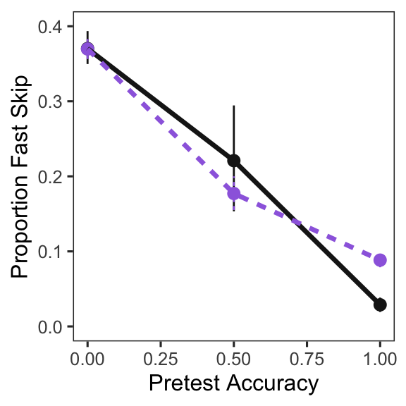

```r
df %>%
    filter(!(correct & (rt < 1000))) %>%
    mutate(y = as.numeric(skip & rt < 1000)) %>%
    # mutate(y = as.numeric(rt > 1000)) %>%
    ggplot(aes(pre_correct, y, color=name, linetype=name)) +
    stat_summary(fun.data=mean_cl_boot, size=.5) +
    stat_summary(fun=mean, geom="line") +
    scale_colour_manual(values=c(
        'Human'='gray10',
        'Model'='#9D6BE0'
    ), aesthetics=c("fill", "colour"), name="") +
    theme(legend.position="none") +
    coord_cartesian(xlim=c(NULL), ylim=c(0, 0.4)) +
    labs(x="Pretest Accuracy", y="Proportion Fast Skip")
```